# Projekt1-etap3

Filip Binkiewicz, Wojciech Szymański

## Klasyfikatoy

Wczytujemy plik Rak, w którym znajdują się już oczyszczone dane Glioblastomawide, tzn. kolumna `death1y` zawiera wartości zerojedynkowe, kolumny, które zaierają więcej niż pięć wartości `NA` dla pacjentów, którzy przeżyli oraz więcej niż pięć wartości `NA` dla pacjentów, którzy nie przeżyli zostały usunięte, a w pozostałych kolumnach `NA` zostały zastąpione średnimi kolumn.

W pierwszej fazie projektu otrzymaliśmy zbiór istotnych zmiennych, który teraz przypiszemy na wektorze `Nazwy`. Na podtawie tych cech zbudujemy kilka klasyfikatorów w celu oceny śmiertelności wśród chorych.

```r
load("C:/Users/ojro72/Desktop/Rak.rda")

Nazwy <- c("death1y","age","ACTR3C","AQP9","CLEC5A","CSNK1D","CTSB","CTSD","GPNMB","HK3","LRRC61","LSP1","MLPH","NCF2","NRG1","PLAUR","SLC11A1","SLC17A9","STAG2","STC1","TBL1XR1")
Zbior_Cechy <- Rak[,Nazwy]
Zbior_Cechy$death1y <- as.factor(Zbior_Cechy$death1y)
```

## Klasyfikatory

### 1. Las

Pierwszym klasyfikatorem jest las losowy, który wywołamy przy użyciu funkcji `randomForest`

```r
set.seed(13)
LAS<-randomForest(death1y~.,data=Zbior_Cechy)
LAS
```

```
##
## Call:
##  randomForest(formula = death1y ~ ., data = Zbior_Cechy)
##                Type of random forest: classification
##                      Number of trees: 500
## No. of variables tried at each split: 4
##
##         OOB estimate of  error rate: 32%
## Confusion matrix:
##    0  1 class.error
## 0 42 21   0.3333333
## 1 19 43   0.3064516
```

```r
importance(LAS)
```

```
##         MeanDecreaseGini
## age             3.300668
## ACTR3C          3.172703
## AQP9            2.171442
## CLEC5A          3.054975
## CSNK1D          4.865113
## CTSB            2.597970
## CTSD            2.595941
## GPNMB           3.392269
## HK3             2.073854
## LRRC61          3.815049
## LSP1            3.826582
## MLPH            2.769941
## NCF2            2.515217
## NRG1            3.569997
## PLAUR           2.365411
## SLC11A1         1.899108
## SLC17A9         4.171103
## STAG2           2.642646
## STC1            3.049266
## TBL1XR1         4.106713
```

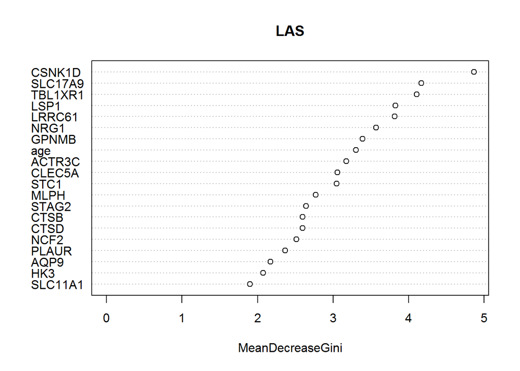

```r
varImpPlot(LAS)
```

Powyższy wykres przedstawia istotność cech dla lasu losowego. Widzimy, że najbardziej istotne są `CSNK1D` i `SLC17A9`. Zbudujmy zatem obszar decyzyjny dla tych cech

#### Obszar decyzyjny dla `CSNK1D` i `SLC17A9`

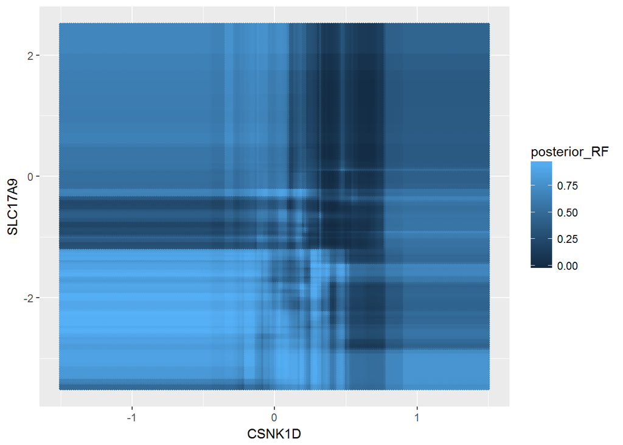

Obszar ten interpretujemy następująco. Jaśniejsze pole oznacza duże prawdopodobieństwo przeżycia, natomiast ciemny obszar oznacza małe prawdopodobieństwo przetrwania pacjenta

#### K-fold cross-walidacja dla lasu

Jakość klasyfikotora będziemy badać porównując błąd cross-walidacji. W naszym przypadku powtórzymy 20-krotnie 10-fold cv. Na każdym z podzbiorów sprawdzamy trafność predykcji modelu zbudowanego na pozostałych zbiorach. `0` oznacza, że model trafnie przewidział stan pacjenta, `-1` oznacza, że model nietrafnie przewidział śmierć pacjenta, `1` oznacza, że model nietrafnie przewidział przeżycie pacjenta. Tworzymy histogram, a następnie uśredniamy błąd cross-walidacji.

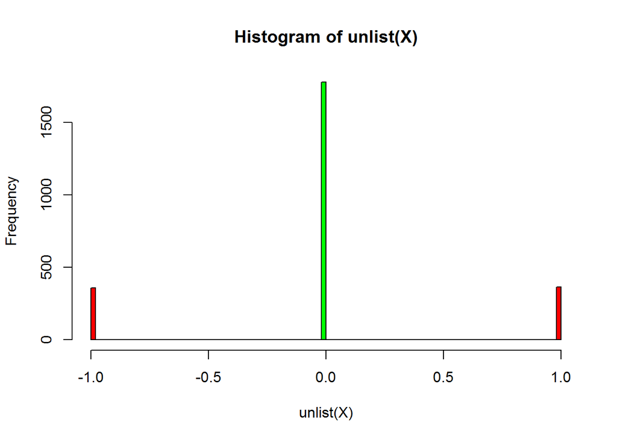

```r
set.seed(13)
X <- replicate(20,{
foldy <- createFolds(Zbior_Cechy$death1y, k = 10)
lapply(foldy, function(x) {
  model <- randomForest(death1y~.,data=Zbior_Cechy[-x,])
  round(as.numeric(predict(model,newdata=Zbior_Cechy[x,], type="prob")[,2])) -
  (as.numeric(Zbior_Cechy[x,"death1y"])-1)
})
})

hist(unlist(X),100, col=c("red","green","red"))
```

```r
mean(abs(unlist(X)))
```

```
## [1] 0.2892
```

#### Krzywa ROC dla lasu

Kolejną metodą porównywania jakośći klasyfikotorów jest krzywa ROC. Interpretacja tej metody jest prosta, im większe pole pod wykresem tym lepsza predykcja, czyli lepszy klasyfikator

Średnia krzywa ROC dla 10-fold cv

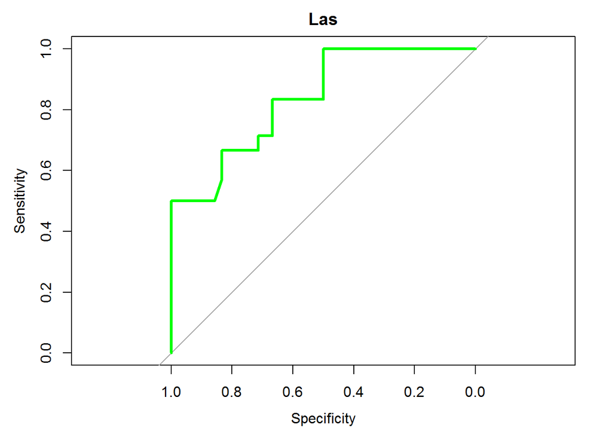

Średnie pole pod wykresem dla 20-krotnie powtórzonego 10-fold cv

```
## [1] 0.7860473
```

### 2. Xgboost

Kolejnym klasyfikatorem jest xgboost, który wywołamy przy użyciu funkcji `xgboost`

```r
GB <- xgboost(label=Zbior_Cechy$death1y == "1",
              data=as.matrix(Zbior_Cechy[,-1]),
              objective = "binary:logistic",
              nrounds=10, max.deph = 10)
```

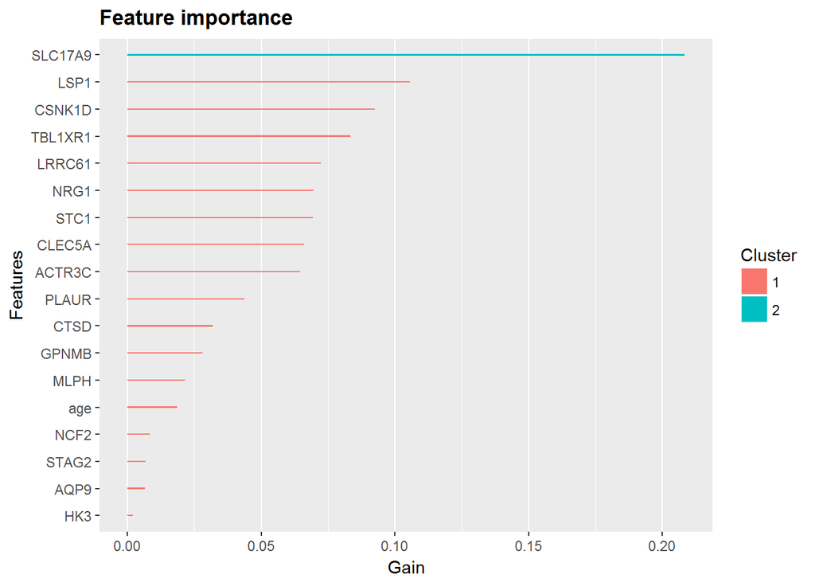

```r
importance_matrix <- xgb.importance(colnames(Zbior_Cechy)[-1], model = GB)
xgb.plot.importance(importance_matrix)
```

Powyższy wykres przedstawia istotność cech dla xgboost. Widzimy, że najbardziej istotne jest `SLC17A9`

#### K-fold cross-walidacja dla xgboost (histogram, średni błąd)

```r
Y <- replicate(20,{
foldy <- createFolds(Zbior_Cechy$death1y, k = 10)
lapply(foldy, function(x) {
    Zbior_Trening <- Zbior_Cechy[-x,]
    Zbior_Testowy <- Zbior_Cechy[x,]
model <- xgboost(label=Zbior_Trening$death1y == "1",
                 data=as.matrix(Zbior_Trening[,-1]),
                 objective = "binary:logistic",
                 nrounds=9, max.deph = 10)
round(predict(model, as.matrix(Zbior_Testowy[,-1]))) -
  (as.numeric(Zbior_Testowy[,"death1y"])-1)
})
})
```

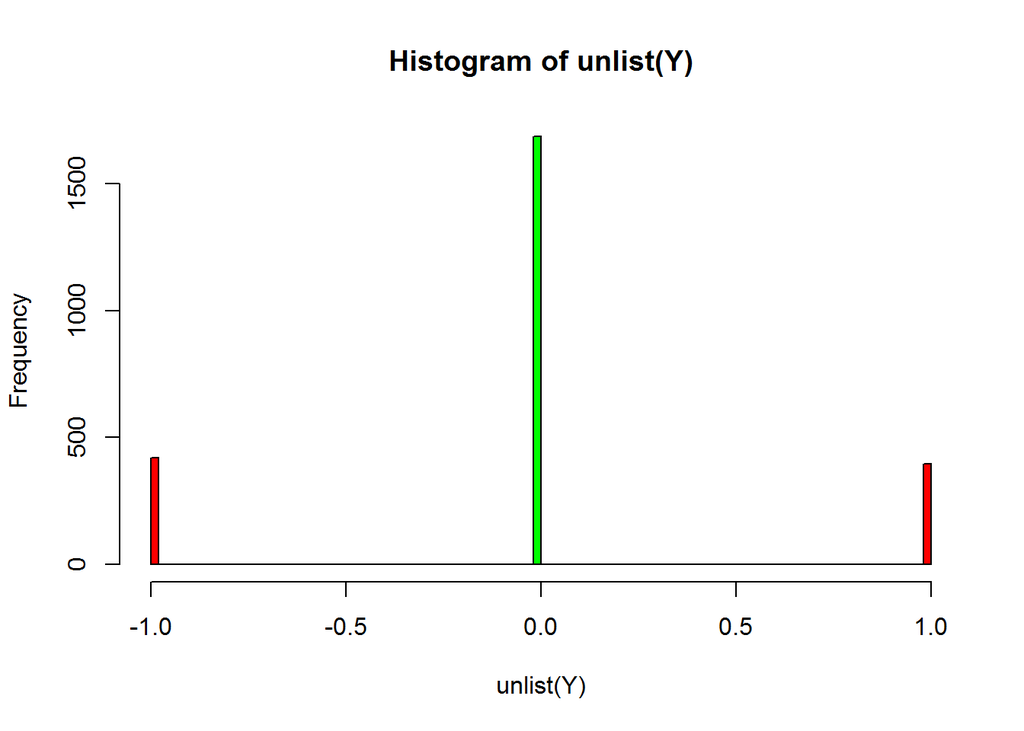

```r
hist(unlist(Y), 100, col=c("red","green","red"))
```

```r
mean(abs(unlist(Y)))
```

```
## [1] 0.326
```

#### Krzywa ROC dla xgboost

Średnia krzywa ROC dla 10-fold cv

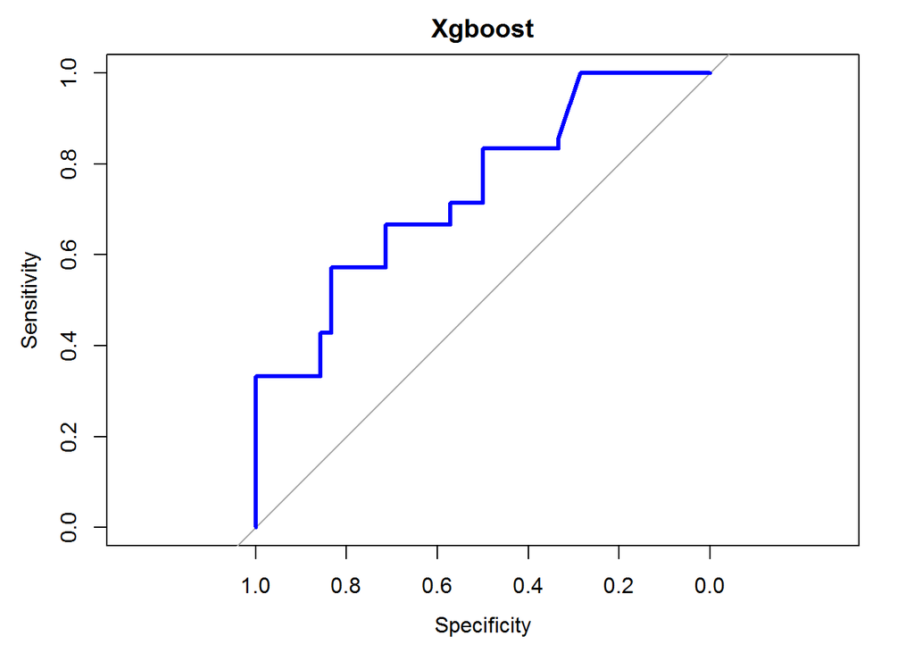

Średnie pole pod wykresem dla 20-krotnie powtórzonego 10-fold cv

```
## [1] 0.7326304
```

### 3. LASSO glm

Następnym klasyfikatorem jest LASSO glm wywołany przy użyciu funkcji `cv.glmnet`

```r
CV<-cv.glmnet(x=as.matrix(Zbior_Cechy[,-1]),
              y=Zbior_Cechy$death1y == "1",
              family="binomial")
```

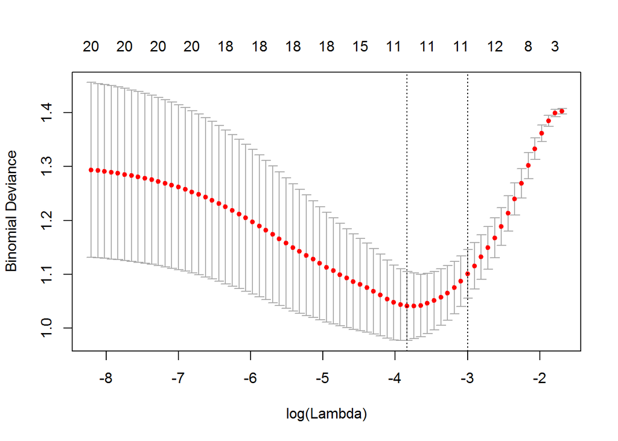

#### K-fold cross-walidacja dla LASSO glm (histogram, średni błąd)

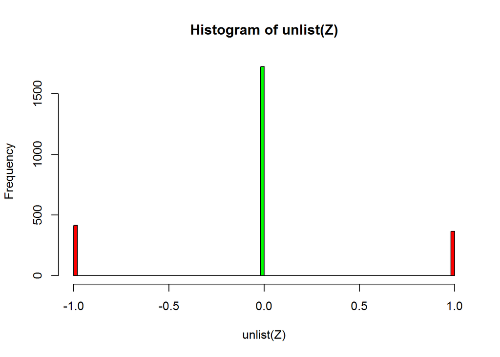

```r
Z <- replicate(20,{
foldy <- createFolds(Zbior_Cechy$death1y, k = 10)
lapply(foldy, function(x) {
    Zbior_Trening <- Zbior_Cechy[-x,]
    Zbior_Testowy <- Zbior_Cechy[x,]
model <- cv.glmnet(x=as.matrix(Zbior_Trening[,-1]),
                   y=Zbior_Trening$death1y == "1",
                   family="binomial")
round(as.numeric(predict(model, as.matrix(Zbior_Testowy[,-1]), type="response"))) - (as.numeric(Zbior_Testowy$death1y)-1)
})
})
hist(unlist(Z),100, col=c("red","green","red"))
```

```r
mean(abs(unlist(Z)))
```

```
## [1] 0.3116
```

#### Krzywa ROC dla LASSO glm

Średnia krzywa ROC dla 10-fold cv

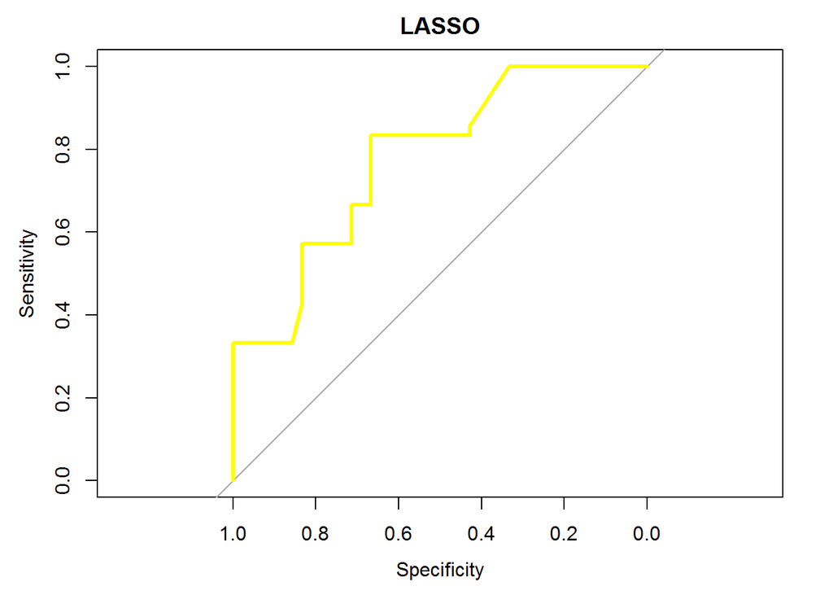

Średnie pole pod wykresem dla 20-krotnie powtórzonego 10-fold cv

```
## [1] 0.7812245
```

### 4. Regresja logistyczna

Kolejny klasyfikator to regresja logistyczna zbudowana przy użyciu funkcji `glm`

```r
Regresja <- glm(death1y~.,Rak[,Nazwy], family="binomial")
summary(Regresja)
```

```
##
## Call:
## glm(formula = death1y ~ ., family = "binomial", data = Rak[,
##     Nazwy])
##
## Deviance Residuals:
##     Min       1Q   Median       3Q      Max
## -2.1172  -0.5864  -0.0620   0.6249   3.2733
##
## Coefficients:
##             Estimate Std. Error z value Pr(>|z|)
## (Intercept)  2.57276    2.49484   1.031  0.30243
## age         -0.01876    0.02520  -0.744  0.45668
## ACTR3C      -0.39971    0.31256  -1.279  0.20096
## AQP9        -0.35238    0.29409  -1.198  0.23084
## CLEC5A      -0.37948    0.25764  -1.473  0.14078
## CSNK1D      -4.34538    1.40844  -3.085  0.00203 **
## CTSB        -0.14359    0.79124  -0.181  0.85599
## CTSD         0.91958    0.83850   1.097  0.27278
## GPNMB       -1.05226    0.40920  -2.571  0.01013 *
## HK3          0.82117    0.49700   1.652  0.09848 .
## LRRC61      -0.29230    0.23610  -1.238  0.21570
## LSP1        -0.12990    0.45607  -0.285  0.77577
## MLPH        -0.09499    0.21313  -0.446  0.65581
## NCF2         0.54815    0.72800   0.753  0.45148
## NRG1        -0.33389    0.15218  -2.194  0.02823 *
## PLAUR       -0.67580    0.72744  -0.929  0.35288
## SLC11A1     -0.03332    0.46457  -0.072  0.94282
## SLC17A9      0.36486    0.43396   0.841  0.40048
## STAG2        0.62465    0.83427   0.749  0.45401
## STC1         0.05943    0.25740   0.231  0.81740
## TBL1XR1      2.95132    1.24339   2.374  0.01762 *
## ---
## Signif. codes:  0 '***' 0.001 '**' 0.01 '*' 0.05 '.' 0.1 ' ' 1
##
## (Dispersion parameter for binomial family taken to be 1)
##
##     Null deviance: 173.279  on 124  degrees of freedom
## Residual deviance:  96.523  on 104  degrees of freedom
## AIC: 138.52
##
## Number of Fisher Scoring iterations: 6
```

Ostatnia z kolumn opisujących zmienne objaśniające mówi o istotności każdej ze zmiennych. Jak widzimy większość zmiennych model uznaje jednak za niestotne

#### K-fold cross-walidacja dla regresji logistycznej (histogram, średni błąd)

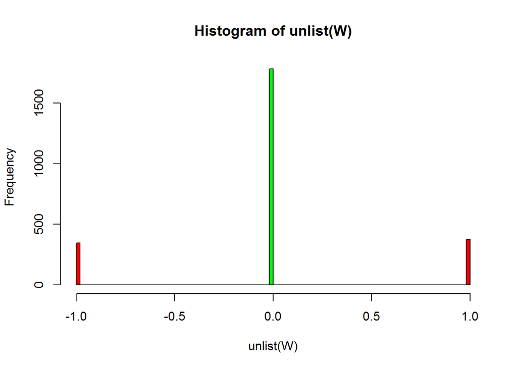

```r
W <- replicate(20,{
foldy <- createFolds(Zbior_Cechy$death1y, k = 10)
  lapply(foldy, function(x) {
  model <- glm(death1y~.,data=Rak[-x,Nazwy])
  round(as.numeric(predict(model,newdata=Rak[x,Nazwy], type="response"))) -
  (as.numeric(Zbior_Cechy[x,"death1y"])-1)
})
})

hist(unlist(W),100, col=c("red","green","red"))
```

```r
mean(abs(unlist(W)))
```

```
## [1] 0.288
```

#### Krzywa ROC dla regresji logistycznej

Średnia krzywa ROC dla 10-fold cv

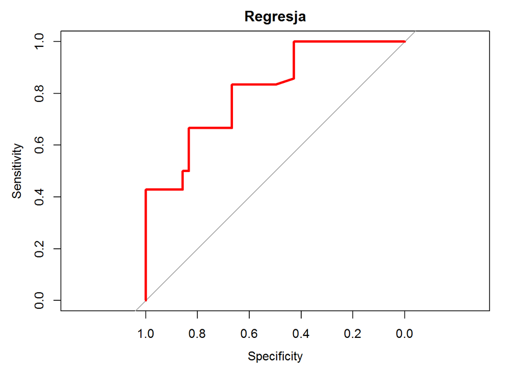

Średnie pole pod wykresem dla 20-krotnie powtórzonego 10-fold cv

```
## [1] 0.801695
```

## Wyniki dla poszczególnych modeli

### Histogramy w wybranych modelach

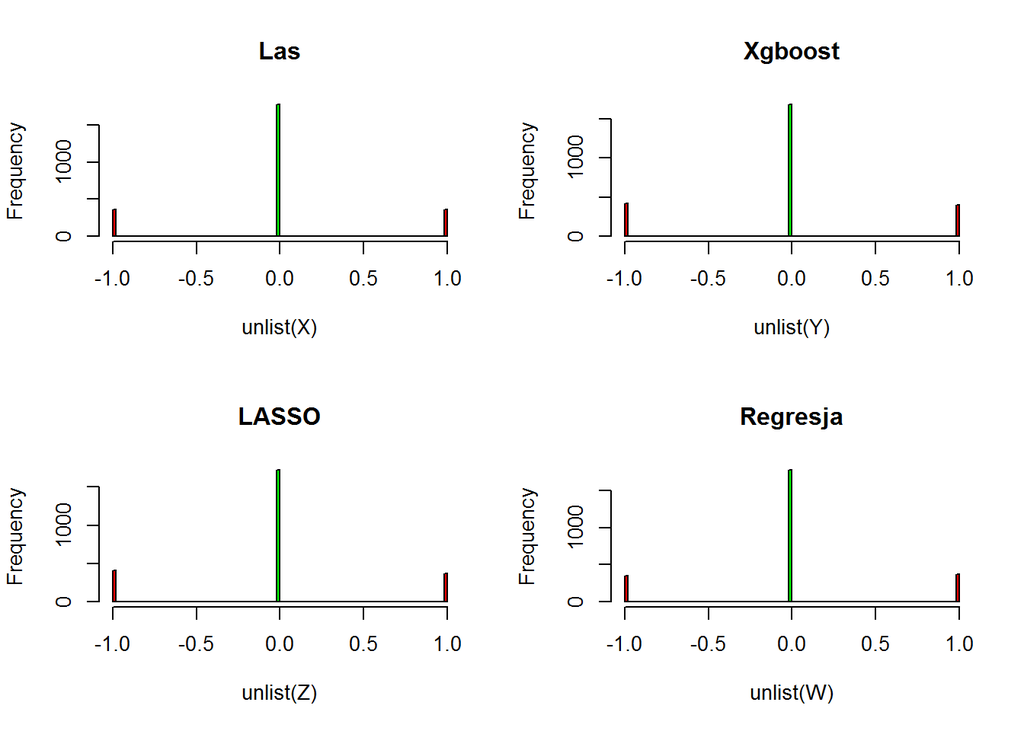

### Średnie krzywe ROC dla modeli dla 10-fold cv

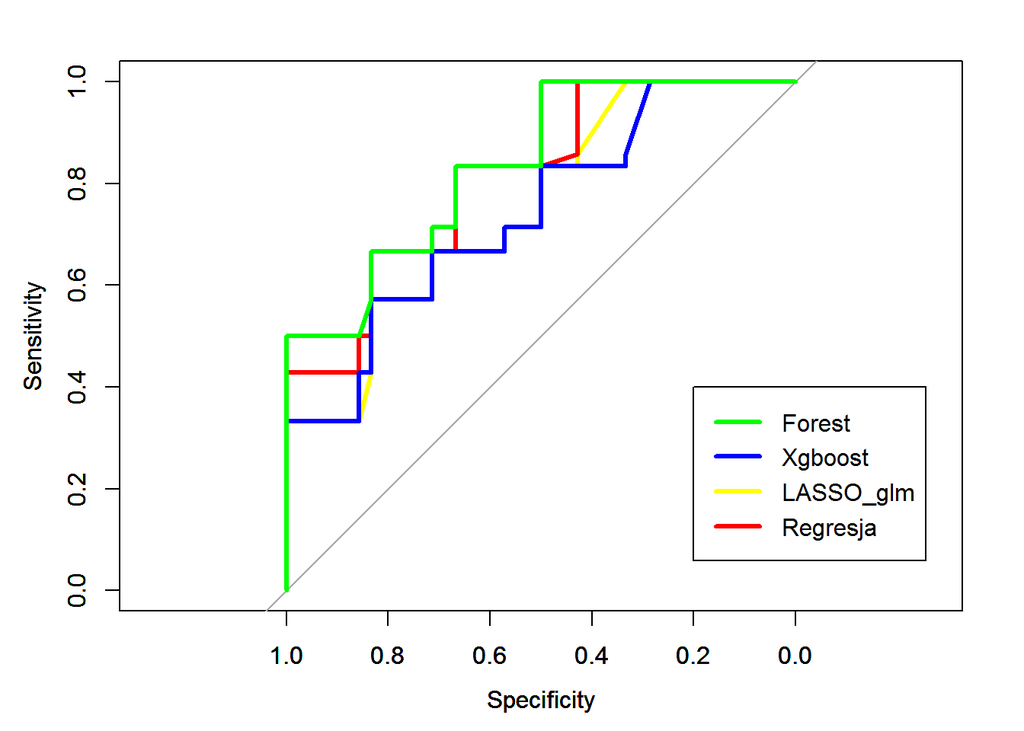

### Błędy k-fold w wybranych modelach dla 20-krotnego 10-fold cv

```
##      Las  Xgboost    LASSO Regresja
##   0.2892   0.3260   0.3116   0.2880
```

### Średnie pole pod wykresem krzywych ROC w wybranych modelach dla 20-krotnego 10-fold cv

```
##       Las   Xgboost     LASSO  Regresja
## 0.7860473 0.7326304 0.7812245 0.8016950
```

Powyższe rezultaty pokazują, że regresja logistyczna jest najlepszym klasyfikatorem, ponieważ ma najmniejszy błąd k-fold i największe pole pod wykresem średnich ROC.

# Model Stack

Zbudujemy teraz kilka klasyfikatorów oparte o model stacking wykorzystujących bibliotekę `caretEnsemble`. Tworzymy listę klasyfikatorów, z których zbudujemy jeden potencjalnie bardziej efektywny model stacking łącząc poszczególne klasyfikatory różnymi metodami. Najpierw zbadajmy jednak poszczególne klasyfikatory z wybranej przez nas listy.

```r
algorithmList <- c('glm', 'rpart', 'knn', 'rf', 'svmRadial')
seed <- 10
```

W naszym modelu 20-krotnie powtórzymy 10-fold cv

```r
control <- trainControl(
  method="repeatedcv",
  number=10,
  repeats=20,
  savePredictions="final",
  classProbs=TRUE
)
```

Definiujemy nowy zbiór training.data, który różni się od Zbior_Cechy tylko tym, że kolumna `death1y` zamiast wartości 0 i 1 przyjmuje w training.data wartości odpowiednio “dead” i “alive”. Do tak utworzonego nowego zbioru dopasowujemy nasze modele wykorzystując wcześniej zdefiniowany `control`

```r
training.data <- Zbior_Cechy
training.data$death1y <- as.factor(ifelse(training.data$death1y == "1","alive","dead"))
set.seed(seed)
models <- caretList(
  death1y~.,
  data=training.data,
  trControl=control,
  methodList=algorithmList
)
results <- resamples(models)
summary(results)
```

```
##
## Call:
## summary.resamples(object = results)
##
## Models: glm, rpart, knn, rf, svmRadial
## Number of resamples: 200
##
## Accuracy
##             Min. 1st Qu. Median   Mean 3rd Qu.   Max. NA's
## glm       0.3846  0.6667 0.7500 0.7262  0.8333 1.0000    0
## rpart     0.2857  0.5385 0.6154 0.6033  0.6667 0.8571    0
## knn       0.1538  0.5833 0.6923 0.6835  0.7692 1.0000    0
## rf        0.2500  0.6154 0.6923 0.7059  0.7976 1.0000    0
## svmRadial 0.3333  0.6154 0.6923 0.7133  0.8333 1.0000    0
##
## Kappa
##              Min. 1st Qu. Median   Mean 3rd Qu.   Max. NA's
## glm       -0.1818 0.33330 0.5000 0.4518  0.6667 1.0000    0
## rpart     -0.4286 0.04878 0.2169 0.2057  0.3333 0.7143    0
## knn       -0.6824 0.16670 0.3659 0.3654  0.5301 1.0000    0
## rf        -0.5000 0.25290 0.3953 0.4118  0.5952 1.0000    0
## svmRadial -0.3333 0.23530 0.3953 0.4267  0.6667 1.0000    0
```

Widzimy Accuracy i Kappa dla poszczególnych modeli. Współczynnik Accuracy interpretujemy jako skuteczność wybranych modeli, natomiast współczynnik Kappa oznacza częstość przewyższenia trafności klasyfikacji wybranych modeli od trafności klasyfikacji modelu losowego

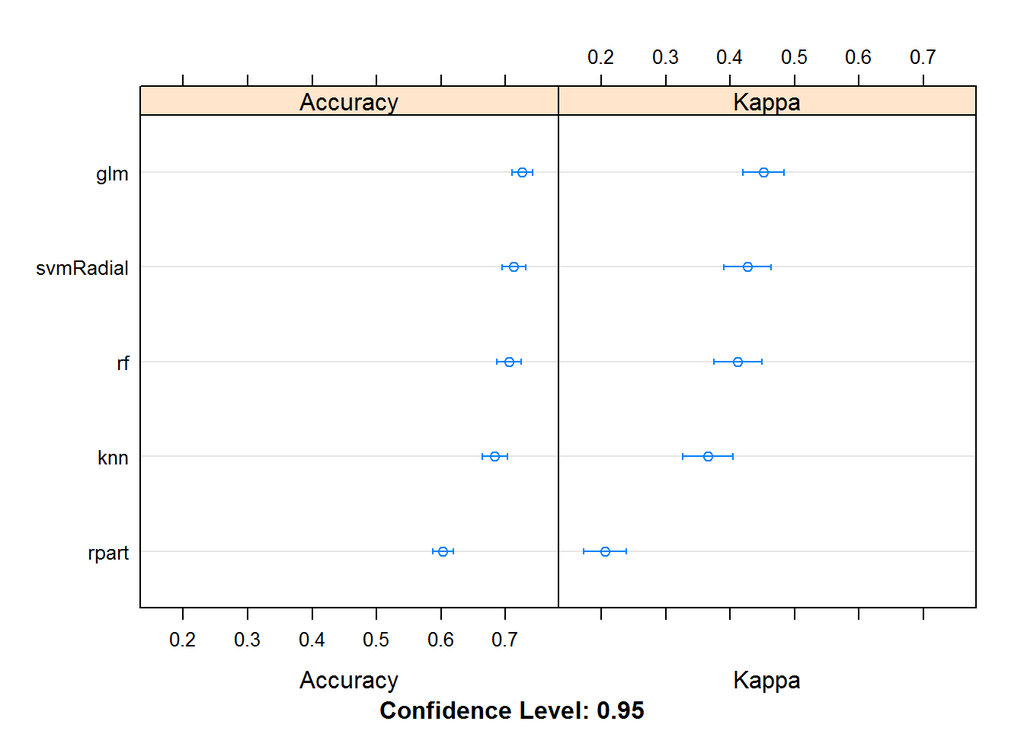

```r
dotplot(results)
```

Zauważamy, że model `glm` tworzy najskuteczniejszy model spośród rozważanych modeli. Ma największy współczynnik Accuracy oraz Kappa

Poniżej przedstawiamy korelację pomiędzy poszczególnymi klasyfikatorami

```r
modelCor(results)
```

```
##                 glm     rpart       knn        rf svmRadial
## glm       1.0000000 0.2569237 0.3022869 0.4574518 0.5670860
## rpart     0.2569237 1.0000000 0.3024035 0.5324598 0.5294697
## knn       0.3022869 0.3024035 1.0000000 0.3867876 0.4294545
## rf        0.4574518 0.5324598 0.3867876 1.0000000 0.7817194
## svmRadial 0.5670860 0.5294697 0.4294545 0.7817194 1.0000000
```

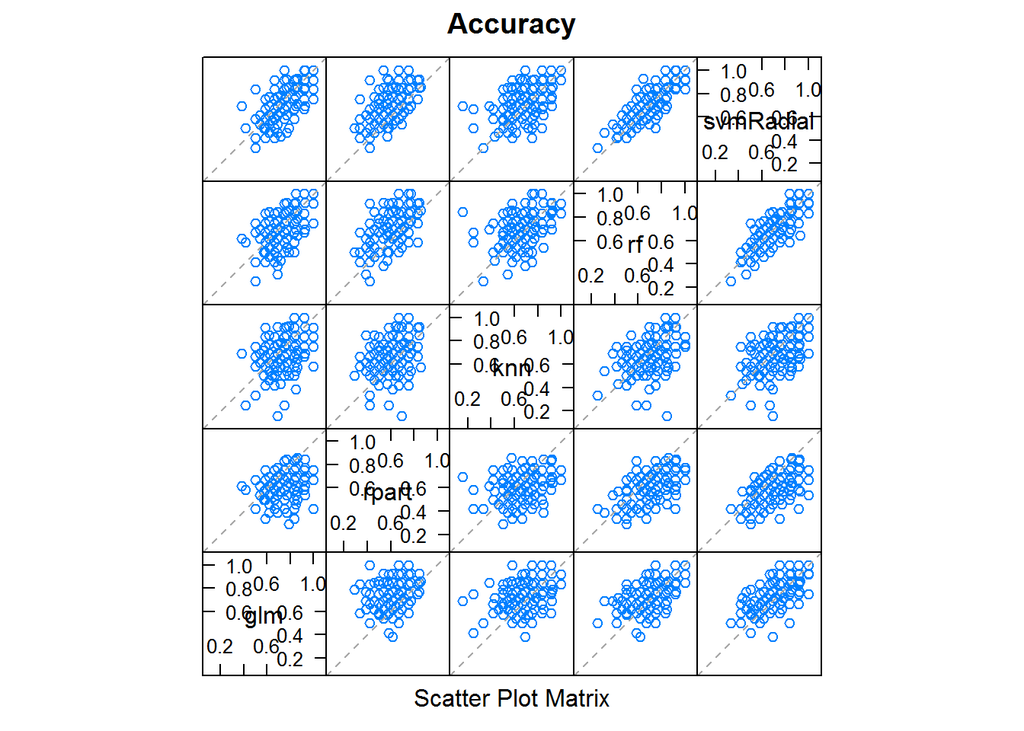

```r
splom(results)
```

Gęsty rozkład punktów na przekątnej oznacza silną korelację pomiędzy modelami, natomiast rozproszenie punktów oznacza słabą korelację

## Modele stacking

Przechodzimy teraz do tworzenia modeli stacking zbudowanych różnymi metodami z listy wybranych klasyfikatorów. Zaprezentujemy trzy metody budowy: `glm`, `rf` oraz `gbm`

### 1.Model stacking zbudowany metodą `glm`

```r
stack.glm <- caretStack(
  models,
  method="glm",
  metric="Accuracy",
  trControl=control
)

print(stack.glm)
```

```
## A glm ensemble of 2 base models: glm, rpart, knn, rf, svmRadial
##
## Ensemble results:
## Generalized Linear Model
##
## 2500 samples
##    5 predictor
##    2 classes: 'alive', 'dead'
##
## No pre-processing
## Resampling: Cross-Validated (10 fold, repeated 20 times)
## Summary of sample sizes: 2250, 2250, 2250, 2250, 2250, 2250, ...
## Resampling results:
##
##   Accuracy  Kappa
##   0.7394    0.478681
##
##
```

Jak widzimy współczynnik Accuracy niewiele poprawił się w stosunku do zwykłego modelu `glm`

### 2.Model stacking zbudowany metodą `rf`

```r
stack.rf <- caretStack(
  models,
  method="rf",
  metric="Accuracy",
  trControl=control
)

print(stack.rf)
```

```
## A rf ensemble of 2 base models: glm, rpart, knn, rf, svmRadial
##
## Ensemble results:
## Random Forest
##
## 2500 samples
##    5 predictor
##    2 classes: 'alive', 'dead'
##
## No pre-processing
## Resampling: Cross-Validated (10 fold, repeated 20 times)
## Summary of sample sizes: 2250, 2250, 2250, 2250, 2250, 2250, ...
## Resampling results across tuning parameters:
##
##   mtry  Accuracy  Kappa
##   2     0.88040   0.7608023
##   3     0.87982   0.7596485
##   5     0.87460   0.7492009
##
## Accuracy was used to select the optimal model using  the largest value.
## The final value used for the model was mtry = 2.
```

### 3.Model stacking zbudowany metodą `gbm`

```r
stack.gbm <- caretStack(
  models,
  method="gbm",
  metric="Accuracy",
  trControl=control
)
```

```r
print(stack.gbm)
```

```
## A gbm ensemble of 2 base models: glm, rpart, knn, rf, svmRadial
##
## Ensemble results:
## Stochastic Gradient Boosting
##
## 2500 samples
##    5 predictor
##    2 classes: 'alive', 'dead'
##
## No pre-processing
## Resampling: Cross-Validated (10 fold, repeated 20 times)
## Summary of sample sizes: 2250, 2250, 2250, 2250, 2250, 2250, ...
## Resampling results across tuning parameters:
##
##   interaction.depth  n.trees  Accuracy  Kappa
##   1                   50      0.73800   0.4762100
##   1                  100      0.75406   0.5082855
##   1                  150      0.76176   0.5236100
##   2                   50      0.76408   0.5283005
##   2                  100      0.78436   0.5687346
##   2                  150      0.79980   0.5995932
##   3                   50      0.78594   0.5719320
##   3                  100      0.80942   0.6188521
##   3                  150      0.82202   0.6440351
##
## Tuning parameter 'shrinkage' was held constant at a value of 0.1
##
## Tuning parameter 'n.minobsinnode' was held constant at a value of 10
## Accuracy was used to select the optimal model using  the largest value.
## The final values used for the model were n.trees = 150,
##  interaction.depth = 3, shrinkage = 0.1 and n.minobsinnode = 10.
```

Widzimy poprawę modelu. Współczynnik Accuracy wyniósł jest wyższy od Accuracy `glm`, co daje wzrost w stosunku do modelu `glm`, ale jest on gorszy od modelu stacking zbudowanego metodą `rf`

### Podsumowanie

Badaliśmy jakość poszczególnych klasyfikatorów porównując średnie błędy 20 krotnie powtórzonych 10-fold cross-walidacji oraz średnie pola krzywych ROC. Skorzystaliśmy również z biblioteki `caretEnsemble`, porównując współczynniki Accuracy i Kappa dla wybranych modeli. Wśród rozważanych modeli najlepsza była regresja logistyczna. Budując jednak model stacking metodą `rf` z wybranej listy klasyfikatorów udało nam się zwiększyć efektywność klasyfikatora. Na podstawie największych współczynników Accuracy oraz Kappa wśród rozważanych modeli stwierdzamy iż najlepszym klasyfikatorem okazał się model stacking zbudowany metodą `rf`.